# AD mice - MS1-only

Loading necessary libraries

```r
library(renv) #remotes::install_github("rstudio/renv")
#renv::restore()
library(tidyverse)
library(stringr)
library(DESeq2)
library(data.table)
library(dendextend)
library(here)
library(impute)
library(pvclust)
library(gplots)
library(RColorBrewer)
library(cluster)
library(cutr)#devtools::install_github("moodymudskipper/cutr")
library(caret)
#library(mlbench)
#library(MASS)
#library(glmnet)
#library(foreach)
#library(doParallel)
#registerDoParallel(cores=2)
library(stringr)
library(lubridate)
library(umap)
#library(sva)
#renv::snapshot()
```

# Loading in data

```r
### For the openMS files
## will have to edit...
## sample info ../data/ms1_openms_sampleinfo.csv
ad_samples <-  read.delim(here::here("Dataset5-AD_mice", "data", "ms1feature_info.txt"), sep='\t', header=F) %>%
    mutate_if(is.character, str_trim)
ad_metadata <- read.csv(here::here("Dataset5-AD_mice", "data", "experimentalGroups.csv"))
ad_metadata <- left_join(ad_samples, ad_metadata, by = c("V3" = "Name"))


features <- read.delim(here::here("Dataset5-AD_mice", "data", "ms1features.txt"), sep='\t')
consensus_features <- features%>% dplyr::select(.,contains("cf")) %>%
    mutate(feat_num = 1:nrow(features))
ms1 <- features %>% dplyr::select(.,-contains("cf"))
rt <- ms1 %>% dplyr::select(.,contains("rt"))
mz <- ms1 %>% dplyr::select(.,contains("mz"))
charge <-  ms1 %>% dplyr::select(.,contains("charge"))
intensity <- ms1 %>% dplyr::select(., contains("intensity")) %>% as.data.frame()

ad_metadata <- ad_metadata %>%
    mutate(NewName = paste0(Mouse, "_", Condition))
colnames(intensity) <- ad_metadata$NewName

# reorganize df so that it's in the order of conditions (for filtering)
ad_metadata <- ad_metadata %>%
    arrange(., Condition)
#intensity_info <- intensity %>% dplyr::select(feature_num, RT,MZ)
intensity <- intensity %>% dplyr::select(ad_metadata$NewName)
#colnames(intensity) <- paste0(colnames(intensity), "_", ibd_meta$Diagnosis)
intensity <- intensity %>% mutate(feat_num = 1:nrow(intensity))
```

We want to filter the data by missing values and low intensity values. MS1 data is inherently noisy, and so we also filter by low intensity. In this case, we identify intensity quartiles and consider the lowest quartile missing values **only** for the filtering step. We will keep these values for clustering.

```r
int <- intensity  %>%  dplyr::select(-feat_num) %>% as.data.frame %>% pivot_longer(names_to = "Name", values_to="intensity", cols=everything()) %>% drop_na()
head(int)
```

| Name | intensity |
| --- | --- |
| M007_AD_drug_CT10 | 885000 |
| M009_AD_drug_CT10 | 2630000 |
| M011_AD_drug_CT10 | 1660000 |
| M003_AD_drug_CT14 | 807000 |
| M016_AD_drug_CT14 | 806000 |
| M017_AD_drug_CT14 | 518000 |

```r
summary(int$intensity)
```

```
     Min.   1st Qu.    Median      Mean   3rd Qu.      Max.
2.890e+03 1.000e+06 2.210e+06 7.871e+06 5.310e+06 7.520e+09
```

```r
int_4_quartiles <- smart_cut(int$intensity,4,"groups", labels = c("remove", "Low", "Med", "High"))
table(int_4_quartiles)
```

```
int_4_quartiles
remove    Low    Med   High
130804 131594 132320 131682
```

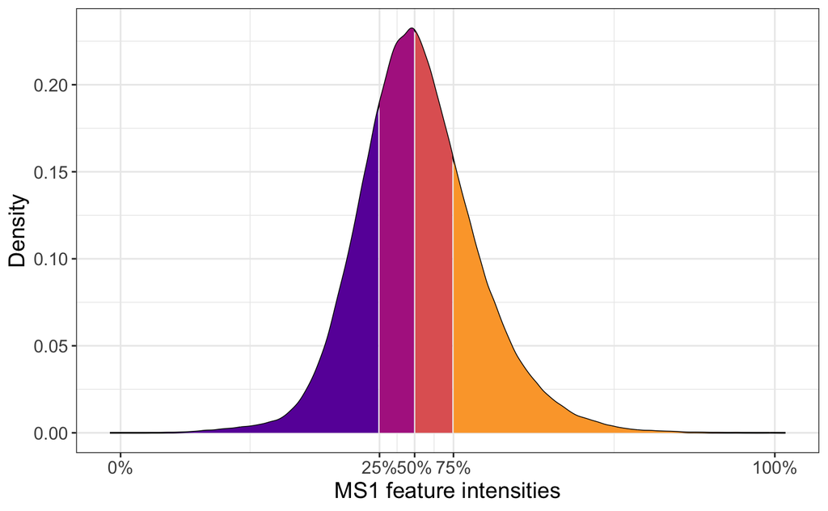

```r
int$quart <- int_4_quartiles
max_to_remove <- int %>% filter(quart == "remove")
max_to_remove <- max_to_remove$intensity %>% max()

dens <- density(log2(int$intensity))
df <- data.frame(x=dens$x, y=dens$y)
probs <- c(0,0.25,0.5,0.75,1)
quantiles <- quantile(log2(int$intensity), prob=probs)
df$quant <- factor(findInterval(df$x,quantiles))


(pep_quart_plot <- ggplot(df, aes(x,y)) + geom_line() +
    geom_ribbon(aes(ymin=0, ymax=y, fill=quant)) +
    scale_x_continuous(breaks=quantiles) +
    #scale_fill_brewer(guide="none") +
    xlab("MS1 feature intensities") +
    ylab("Density") +
    scale_fill_viridis_d(option = "plasma", guide = "none") +
    theme_bw() +
    theme(text=element_text(size=14))
)
```

```r
cond_options_all <- table(ad_metadata$Condition) %>% as.data.frame()
cond_opts_all <- cond_options_all$Var1
cond_count_all <- cond_options_all$Freq * 0.5


is.nan.data.frame <- function(x){
    do.call(cbind, lapply(x, is.nan))}
#df = intensity
#conditions = cond_opts
#min_count = cond_count
## add condition to end of all col names...
filter_valids_quart = function(df, conditions, min_count, int_remove, at_least_one = TRUE) {
    df[is.nan.data.frame(df)] <- 0
    df[is.na(df)] <- 0
    df[df <= int_remove] <- 0
    all_names <- colnames(df)
    cond.names = lapply(conditions, # Group column names by conditions
                        function(x) grep(x, all_names, value = TRUE, perl = TRUE))
    cond.filter = sapply(1:length(cond.names), function(i) {
        df2 = df %>% dplyr::select(cond.names[[i]])   # Extract columns of interest
        df2 = as.matrix(df2)   # Cast as matrix for the following command
        sums = rowSums(df2!=0) # count the number of valid values for each condition
        sums >= min_count[i]   # Calculates whether min_count requirement is met
    })
    if (at_least_one) {
        df$KEEP = apply(cond.filter, 1, any)
    } else {
        df$KEEP = apply(cond.filter, 1, all)
    }
    return(df)  # only keeping rows that meet the criteria!
}



## filter by at least Q50 in each treatment considering ZEROS and anything in low quartile
## trying without any quartile adjustment!
ad_filt <- filter_valids_quart(intensity[,-24],
                               conditions = cond_opts_all,
                               min_count = cond_count_all,
                               int_remove = max_to_remove,
                               at_least_one = T) #78,808
ad_filt <- intensity[ad_filt$KEEP == 1,-24] ## 27041
filt_feat <- rownames(ad_filt)


norm_feat<- estimateSizeFactorsForMatrix(ad_filt)
norm_int <- sweep(ad_filt, 2, norm_feat, "/") ##peptides are normalized

int <- norm_int %>% as.data.frame %>% pivot_longer(names_to = "Name", values_to="intensity", cols=everything()) %>% drop_na()
head(int)
```

| Name | intensity |
| --- | --- |
| M007_AD_drug_CT10 | 992342.5 |
| M009_AD_drug_CT10 | 1232321.0 |
| M011_AD_drug_CT10 | 1111987.5 |
| M003_AD_drug_CT14 | 1210248.3 |
| M016_AD_drug_CT14 | 1186504.4 |
| M017_AD_drug_CT14 | 1495519.5 |

```r
summary(int$intensity)
```

```
     Min.   1st Qu.    Median      Mean   3rd Qu.      Max.
1.674e+04 1.325e+06 2.468e+06 7.586e+06 5.410e+06 4.307e+09
```

```r
int_4_quartiles <- smart_cut(int$intensity,4,"groups", labels = c("remove", "Low", "Med", "High"))
table(int_4_quartiles)
```

```
int_4_quartiles
remove    Low    Med   High
103516 103563 103536 103552
```

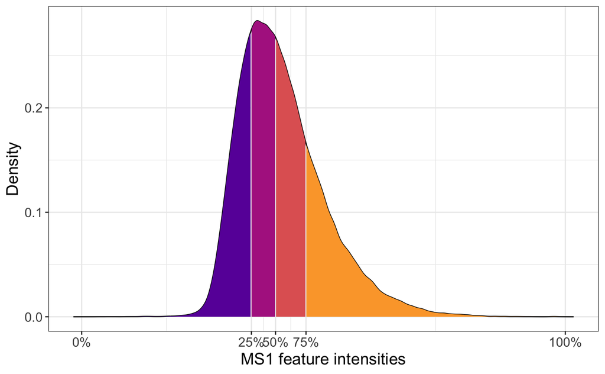

```r
int$quart <- int_4_quartiles
#max_to_remove <- int %>% filter(quart == "remove")
#max_to_remove <- max_to_remove$intensity %>% max()

dens <- density(log2(int$intensity))
df <- data.frame(x=dens$x, y=dens$y)
probs <- c(0,0.25,0.5,0.75,1)
quantiles <- quantile(log2(int$intensity), prob=probs)
df$quant <- factor(findInterval(df$x,quantiles))


(pep_quart_plot <- ggplot(df, aes(x,y)) + geom_line() +
    geom_ribbon(aes(ymin=0, ymax=y, fill=quant)) +
    scale_x_continuous(breaks=quantiles) +
    #scale_fill_brewer(guide="none") +
    xlab("MS1 feature intensities") +
    ylab("Density") +
    scale_fill_viridis_d(option = "plasma", guide = "none") +
    theme_bw() +
    theme(text=element_text(size=14))
)
```

## Missing data imputation

Although we filtered data, we are still left with missing values that will cause challenges with log transformation and fold change calculations. We used a KNN data imputation.

```r
## impute missing values
#intensity_0 <- intensity %>%  mutate_all(~replace(., is.nan(.), 0))

imputed_feat <- impute.knn(norm_int %>% as.matrix(), k = 10, rowmax = 0.5, colmax = 0.95, rng.seed = 362436069)
```

[output not shown]

## UMAP

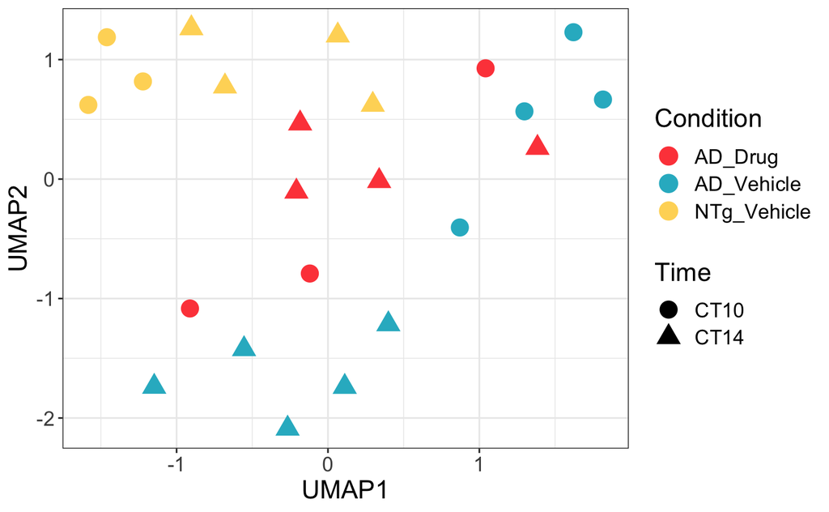

```r
ad_metadata <- ad_metadata %>%
    mutate(AD = ifelse(str_detect(Experiment, "AD"), "AD", "NTg"), #nontransgenic
           Drug = ifelse(str_detect(Experiment, "drug"), "Drug", "Vehicle"),
           Time = ifelse(str_detect(Experiment, "CT10"), "CT10", "CT14"),
           AD_Drug = paste0(AD, "_", Drug))

imputed_noZero <- imputed_feat$data
imputed_noZero[imputed_noZero  == 0] <- 0.0001

log_exp <- data.frame(imputed_noZero) %>%
    mutate_all(., funs(log2(.)))
colnames(log_exp) = colnames(imputed_feat$data)

CT14 <- log_exp %>% select(contains("CT14"))

CT10 <- log_exp %>% select(contains("CT10"))


CT14_umap <- umap(CT14 %>% as.matrix %>% t(), n_components=2, random_state=2248,
                 n_neighbors=10)


CT10_umap <- umap(CT10 %>% as.matrix %>% t(), n_components=2, random_state=2248,
                 n_neighbors=10)
ms1_umap <- umap(log_exp %>% as.matrix %>% t(), n_components=2, random_state=2248)
#ibd_meta <- ibd_meta[match(colnames(log_exp), ibd_meta$NewName),]
coords_umap<-data.frame(ms1_umap$layout,
                        Drug = ad_metadata$Drug,
                        Time = ad_metadata$Time,
                        Condition = ad_metadata$AD_Drug,
                        AD = ad_metadata$AD)

CT14_metadata <- ad_metadata %>% dplyr::filter(NewName %in% colnames(CT14)) %>%
    mutate(check = colnames(CT14))
CT10_metadata <- ad_metadata %>% dplyr::filter(NewName %in% colnames(CT10)) %>%
    mutate(check = colnames(CT10))



CT14_umap<-data.frame(CT14_umap$layout,
                        Drug = CT14_metadata$Drug,
                        Time = CT14_metadata$Time,
                        Condition = CT14_metadata$AD_Drug,
                        AD = CT14_metadata$AD)

CT10_umap<-data.frame(CT10_umap$layout,
                        Drug = CT10_metadata$Drug,
                        Time = CT10_metadata$Time,
                        Condition = CT10_metadata$AD_Drug,
                        AD = CT10_metadata$AD)

(umap_plot_condition <- ggplot(coords_umap, aes(x = X1, y = X2)) +
        geom_point(data = coords_umap, aes(color = Condition,shape = Time, ),
                   size=5) +
        scale_color_manual(values=c("#FE4A49", "#2AB7CA", "#FED766"))+
        scale_x_continuous(name="UMAP1") +
        scale_y_continuous(name="UMAP2") +
        theme_bw() +
        theme(legend.position = "right", text=element_text(size=16)) +
        guides(colour = guide_legend(order = 1),
              shape = guide_legend(order = 2)))
```

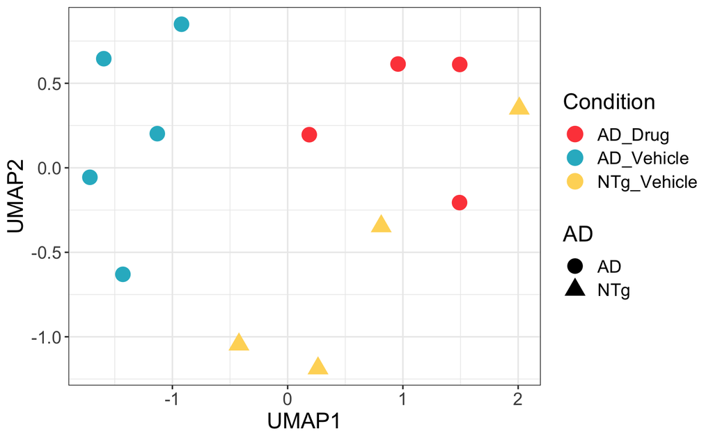

```r
(umap_plot_CT14 <- ggplot(CT14_umap, aes(x = X1, y = X2)) +
        geom_point(aes(color = Condition,shape = AD, ),
                   size=5) +
        scale_color_manual(values=c("#FE4A49", "#2AB7CA", "#FED766"))+
        scale_x_continuous(name="UMAP1") +
        scale_y_continuous(name="UMAP2") +
        theme_bw() +
        theme(legend.position = "right", text=element_text(size=16)) +
        guides(colour = guide_legend(order = 1),
              shape = guide_legend(order = 2)))
```

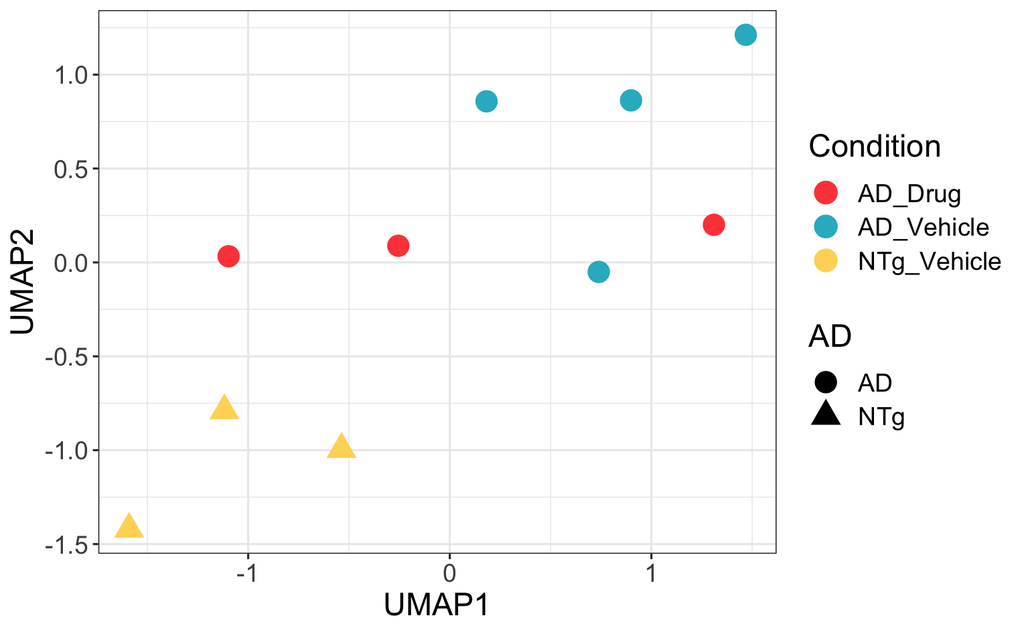

```r
(umap_plot_CT10 <- ggplot(CT10_umap, aes(x = X1, y = X2)) +
        geom_point(aes(color = Condition,shape = AD, ),
                   size=5) +
        scale_color_manual(values=c("#FE4A49", "#2AB7CA", "#FED766"))+
        scale_x_continuous(name="UMAP1") +
        scale_y_continuous(name="UMAP2") +
        theme_bw() +
        theme(legend.position = "right", text=element_text(size=16)) +
        guides(colour = guide_legend(order = 1),
              shape = guide_legend(order = 2)))
```

```r
#ggsave( here::here("Dataset5-AD_mice", "AC-mice_umap.pdf"), umap_plot_condition, width=8, height=6, units="in")
#ggsave( here::here("Dataset5-AD_mice", "CT10", "AC-mice-CT10_umap.pdf"), umap_plot_CT10, width=8, height=6, units="in")
#ggsave( here::here("Dataset5-AD_mice", "CT14", "AC-mice-CT14_umap.pdf"), umap_plot_CT14, width=8, height=6, units="in")
#write.csv(log_exp, here::here("Dataset5-AD_mice","data", "dataset5-ms1_log2_normalized.csv"), quote=F, row.names = T)
#write.csv(CT14, here::here("Dataset5-AD_mice","data", "dataset5-ms1_CT14-log2_normalized.csv"), quote=F, row.names = T)
#write.csv(CT10, here::here("Dataset5-AD_mice","data", "dataset5-ms1_CT10-log2_normalized.csv"), quote=F, row.names = T)
```

## Clustering

Note: we are using [precise-db’s](https://github.com/SBRG/precise-db) ICA implementation. Clustering can be completed the following scripts provided in `bin/`. The ICA implementation of precise-db requires a conda environment which can be accessed using `conda activate precise-db`.

Once ICA has completed it’s run, you will find `S.csv` (and other relevent files) in your chosen output directory. We will be clustering this matrix using `kmed_clustering.py` This script was written considering the newest versions of used packages, thus, `kmed_clustering.py` also has it’s own `conda` environment named `k-med`.

The following should be run in your terminal and requires `conda` and `python`.

```r
## THIS IS A SHELL SCRIPT
## It is best to run this in it's own terminal window because of RStudio's memory limitations
cd ./bin
# You will need to create a specific conda environment for ICA.
# Uncomment the code below to create the environment
# conda env create -f environment.yml
conda activate precise-db
## script for robust ICA matrix decomposition
## Update -n to as many threads you have available; ideally at least 6
## However this will run on a laptop with fewer cores, it just may take longer
sh run_ica.sh -i 100 -t 1e-8 -n 6 -o ../Dataset5-AD_mice/ -l ./Dataset5-AD_mice/CT10/ica.log ../Dataset5-AD_mice/data/dataset5-ms1_log2_normalized.csv
conda deactivate

# to create the correct conda environment for clustering
#conda env create -f k-med_env.yml
# This k-medoid clustering relies on newer modules than the ica implementation
conda activate k-med
./kmed_clutering.py -s ../data/Dataset1/S.csv -d ../data/Dataset1/
conda deactivate
```

## Cluster eigenfeature calculation and clustering visualization

After we use `Python` for clustering our relatively large dataset, let’s calculate summary statistics of each peptide cluster considering the peptide intensity values. We will calculate the clusters for all the data together, just CT10 and just CT14

### Clustering all

```r
kmedoid_labels <- read.csv(here::here("Dataset5-AD_mice", "k-med_labels.csv"), header=F) %>% as.vector()

clusterinfopep <- kmedoid_labels %>% data.frame()

max_clust <- kmedoid_labels %>% unique() %>% max()
print(paste("Number of clusters:", max_clust+1))
```

```
[1] "Number of clusters: 10"
```

```r
clusters <- list()

## creating a list that contains intensities of each peptide cluster
for (x in 0:max_clust){
    clustername <- paste("Cluster", x)
    y <- kmedoid_labels[which(kmedoid_labels$V1 == x),,drop=F] %>% rownames()
    intensities <- log_exp[y %>% as.numeric(),] %>% as.data.frame()
    #intensities <- intensities %>% mutate(feat_num = y)
    clusters[[clustername]] <- intensities
}

### eigenfactors
### Singular value decomposition for genome-wide expression data processing and modeling
###  https://doi.org/10.1073/pnas.97.18.10101
## https://www.biostars.org/p/299167/
## eigengenes <- svd(X)$v

svd_clusters <- lapply(clusters, function(x) svd(x)$v)
# grabbing the first principal component
svd1_cluster <- lapply(svd_clusters,  "[", , 1)


clustereigenfactors_svd <- bind_cols(svd1_cluster) %>% data.frame()
```

Complete the correlation with AD mice conditions

```r
## make a factored dataframe of the compounds

datTraits <- data.frame(Condition =  as.factor(ad_metadata$Condition))
rownames(datTraits) <- ad_metadata$NewName
traits <- model.matrix(~ ., data=datTraits,
                       contrasts.arg = lapply(datTraits, contrasts, contrasts=FALSE))
traits <- traits[,-1] ##removing intercept
#moduleTraitCor_pca <- stats::cor(clustereigenfactors_pca, traits, method = "s")
moduleTraitCor_svd <- stats::cor(clustereigenfactors_svd, traits, method = "s")
#colnames(moduleTraitCor_pca) <- colnames(moduleTraitCor_pca) %>% substr(., 10, nchar(colnames(moduleTraitCor_pca)))
colnames(moduleTraitCor_svd) <- colnames(moduleTraitCor_svd) %>% substr(., 10, nchar(colnames(moduleTraitCor_svd)))
```

Now, let’s look at *SVD-derived* eigenfeatures (this is the more common way of calculating an eigenfeature).

```r
module_clust_svd <- hclust(as.dist(1-cor(t(moduleTraitCor_svd), method="pearson")), method="average")
drug_clust_svd <- hclust(as.dist(1-cor(moduleTraitCor_svd, method="pearson")), method="average")
drug_clust_boot_svd <- pvclust(moduleTraitCor_svd, method.hclust="average",
                           method.dist="correlation", nboot=1000,
                           iseed=2248)
```

```
Bootstrap (r = 0.5)... Done.
Bootstrap (r = 0.6)... Done.
Bootstrap (r = 0.7)... Done.
Bootstrap (r = 0.8)... Done.
Bootstrap (r = 0.9)... Done.
Bootstrap (r = 1.0)... Done.
Bootstrap (r = 1.1)... Done.
Bootstrap (r = 1.2)... Done.
Bootstrap (r = 1.3)... Done.
Bootstrap (r = 1.4)... Done.
```

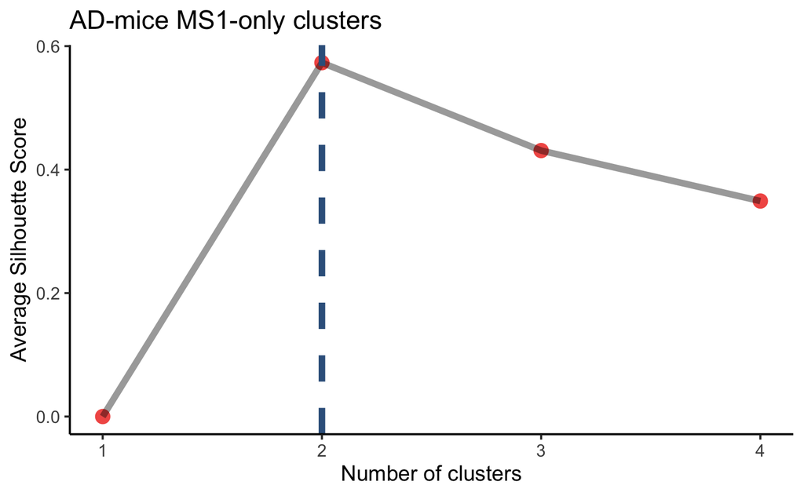

```r
quick_sil <- function(hclust_out, distance, max_k){
  silhouette_score <- function(i){
    k=cutree(hclust_out,i)
    ss <- silhouette(k, 1-cor(distance, method="pearson"))
    mean(ss[, 3])
    }
  clustnum <- 2:max_k
  avg_sil <- sapply(clustnum, silhouette_score)
  avg_sil <- data.frame(num = clustnum, sil_score = avg_sil)
  avg_sil <- rbind(c(1,0), avg_sil)
  return(avg_sil)
}
#
ms1_svd_sil <- quick_sil(hclust_out=drug_clust_svd, distance = 1-cor(moduleTraitCor_svd, method="pearson"), max_k = 4)
(ms1_sil <- ggplot(ms1_svd_sil, aes(x=num, y = sil_score)) +
  geom_point(size=4, colour="#F25C54", alpha=1) +
    geom_line(size=2, alpha=0.4) +
    geom_vline(xintercept=2, size = 2, linetype="dashed", color = "#38618C") +
    xlab("Number of clusters") +
    ylab("Average Silhouette Score") +
    scale_x_continuous(breaks = 1:30) +
    theme_classic(base_size=14) +
    ggtitle("AD-mice MS1-only clusters")
)
```

```r
## Visualize the bootstrap clusters
clust_boot_svd <- as.dendrogram(drug_clust_boot_svd)
#pdf(here::here("figs", "ms1_bootstrap_dend.pdf"), width=9, height =4)
drug_clust_boot_svd %>% as.dendrogram() %>% plot(main = "MS1")
drug_clust_boot_svd %>% text
```

```r
drug_clust_boot_svd %>% pvrect(alpha=0.9, pv="au")
#dev.off()

## colours for dendrogram branches
clust_cols_ms1_svd <- c("#48392A", "#48392A")

ad_dend <- color_branches(as.dendrogram(drug_clust_svd), k = 2, col = clust_cols_ms1_svd) %>%
    set("branches_lwd", 2)

k_2 <- cutree(ad_dend, k = 2, order_clusters_as_data = FALSE)
ad_dend <- branches_attr_by_clusters(
  ad_dend,
  clusters = k_2,
  values = c(1,2),
  attr =  "lty"
)
## metadata for clustr heatmap
# red, blue, yellow
##"#FE4A49", "#2AB7CA", "#FED766"

cor_meta_svd <- data.frame(Sample = labels(ad_dend)) %>%
    mutate(#AD = case_when(str_detect(Sample, 'AD') ~ '#1446A0',
            #              str_detect(Sample, 'NTg') ~ '#DB3069'),
   # Drug = case_when(str_detect(Sample, '-D-') ~ '#F57251',
    #                      str_detect(Sample, '-V-') ~ '#3444DA'),
    Time = case_when(str_detect(Sample, '_CT10') ~ '#131112',
                          str_detect(Sample, '_CT14') ~ '#F7F7FF'),
    Condition = case_when(str_detect(Sample, 'AD_drug') ~ '#FE4A49',
                          str_detect(Sample, 'AD_vehicle') ~ '#2AB7CA',
                          str_detect(Sample, 'NTg_vehicle') ~ '#FED766'))



k_2 <- cutree(ad_dend, k = 2, order_clusters_as_data = FALSE)
ad_dend <- ad_dend %>% set_labels(.,
                                  labels = c("AD_V_10","AD-D-10",
                                             "AD-V-14", "NTg-V-10",
                                             "AD-D-14", "NTg-V-14"))
#ac_ibd_dend <- ac_ibd_dend %>% set_labels(., labels = c("CD", "UC (infl.)",
#                                                        "Control", "CD (infl.)", #"UC"))
pdf(here::here("Dataset5-AD_mice", "AD-mice-dend.pdf"))
```

[figure not shown]

```r
ad_dend %>% plot()
colored_bars(colors = cor_meta_svd %>% dplyr::select(-Sample), dend = ad_dend, sort_by_labels_order = FALSE, y_shift=-0.27)
dev.off()
```

#CLustering CT10

```r
kmedoid_labels_CT10 <- read.csv(here::here("Dataset5-AD_mice", "CT10", "k-med_labels.csv"), header=F) %>% as.vector()

#kmedoid_labels_CT14 <- read.csv(here::here("Dataset5-AD_mice", "CT14", "k-med_labels.csv"), header=F) %>% as.vector()



clusterinfoCT10 <- kmedoid_labels_CT10 %>% data.frame()
#clusterinfoCT14 <- kmedoid_labels_CT14 %>% data.frame()


max_clust_CT10 <- kmedoid_labels_CT10 %>% unique() %>% max()
print(paste("Number of clusters all data points:", max_clust+1))
```

```
[1] "Number of clusters all data points: 10"
```

```r
clusters <- list()
## creating a list that contains intensities of each peptide cluster
for (x in 0:max_clust){
    clustername <- paste("Cluster", x)
    y <- kmedoid_labels_CT10[which(kmedoid_labels_CT10$V1 == x),,drop=F] %>% rownames()
    intensities <- CT10[y %>% as.numeric(),] %>% as.data.frame()
    intensities <- intensities %>% mutate(feat_num = y)
    clusters[[clustername]] <- intensities
}

### eigenfactors
### Singular value decomposition for genome-wide expression data processing and modeling
###  https://doi.org/10.1073/pnas.97.18.10101
## https://www.biostars.org/p/299167/
## eigengenes <- svd(X)$v


svd_clusters <- lapply(clusters, function(x) svd(x %>% dplyr::select(-feat_num))$v)
# grabbing the first principal component
svd1_cluster <- lapply(svd_clusters,  "[", , 1)


clustereigenfactors_svd <- bind_cols(svd1_cluster) %>% data.frame()
```

```r
## make a factored dataframe of the compounds

datTraits <- data.frame(Condition =  as.factor(CT10_metadata$Condition))
rownames(datTraits) <- CT10_metadata$NewName
traits <- model.matrix(~ ., data=datTraits,
                       contrasts.arg = lapply(datTraits, contrasts, contrasts=FALSE))
traits <- traits[,-1] ##removing intercept
#moduleTraitCor_pca <- stats::cor(clustereigenfactors_pca, traits, method = "s")
moduleTraitCor_svd <- stats::cor(clustereigenfactors_svd, traits, method = "s")
#colnames(moduleTraitCor_pca) <- colnames(moduleTraitCor_pca) %>% substr(., 10, nchar(colnames(moduleTraitCor_pca)))
colnames(moduleTraitCor_svd) <- colnames(moduleTraitCor_svd) %>% substr(., 10, nchar(colnames(moduleTraitCor_svd)))
```

Now, let’s look at *SVD-derived* eigenfeatures (this is the more common way of calculating an eigenfeature).

```r
module_clust_svd <- hclust(as.dist(1-cor(t(moduleTraitCor_svd), method="pearson")), method="average")
drug_clust_svd <- hclust(as.dist(1-cor(moduleTraitCor_svd, method="pearson")), method="average")
drug_clust_boot_svd <- pvclust(moduleTraitCor_svd, method.hclust="average",
                           method.dist="correlation", nboot=1000,
                           iseed=2248)
```

```
Bootstrap (r = 0.5)... Done.
Bootstrap (r = 0.6)... Done.
Bootstrap (r = 0.7)... Done.
Bootstrap (r = 0.8)... Done.
Bootstrap (r = 0.9)... Done.
Bootstrap (r = 1.0)... Done.
Bootstrap (r = 1.1)... Done.
Bootstrap (r = 1.2)... Done.
Bootstrap (r = 1.3)... Done.
Bootstrap (r = 1.4)... Done.
```

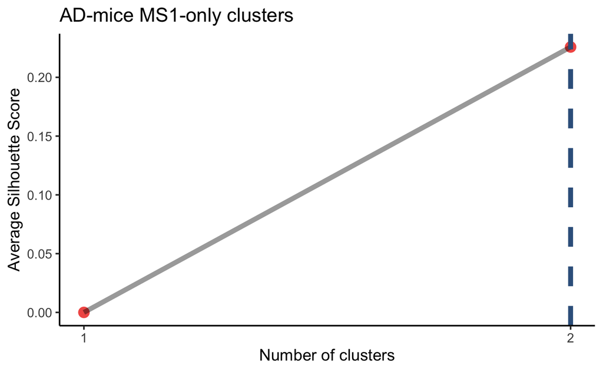

```r
quick_sil <- function(hclust_out, distance, max_k){
  silhouette_score <- function(i){
    k=cutree(hclust_out,i)
    ss <- silhouette(k, 1-cor(distance, method="pearson"))
    mean(ss[, 3])
    }
  clustnum <- 2:max_k
  avg_sil <- sapply(clustnum, silhouette_score)
  avg_sil <- data.frame(num = clustnum, sil_score = avg_sil)
  avg_sil <- rbind(c(1,0), avg_sil)
  return(avg_sil)
}
#
ms1_svd_sil <- quick_sil(hclust_out=drug_clust_svd, distance = 1-cor(moduleTraitCor_svd, method="pearson"), max_k = 2)
(ms1_sil <- ggplot(ms1_svd_sil, aes(x=num, y = sil_score)) +
  geom_point(size=4, colour="#F25C54", alpha=1) +
    geom_line(size=2, alpha=0.4) +
    geom_vline(xintercept=2, size = 2, linetype="dashed", color = "#38618C") +
    xlab("Number of clusters") +
    ylab("Average Silhouette Score") +
    scale_x_continuous(breaks = 1:30) +
    theme_classic(base_size=14) +
    ggtitle("AD-mice MS1-only clusters")
)
```

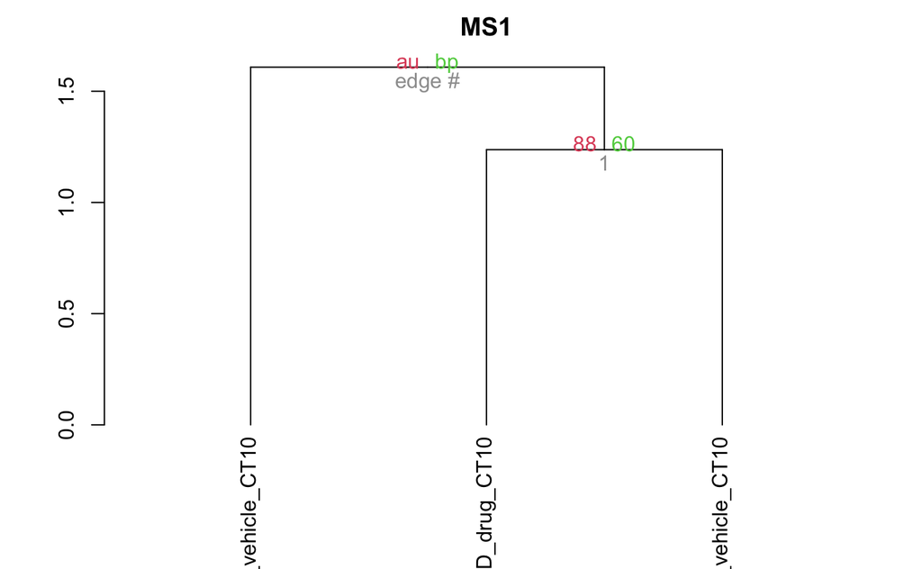

```r
## Visualize the bootstrap clusters
clust_boot_svd <- as.dendrogram(drug_clust_boot_svd)
#pdf(here::here("figs", "ms1_bootstrap_dend.pdf"), width=9, height =4)
drug_clust_boot_svd %>% as.dendrogram() %>% plot(main = "MS1")
drug_clust_boot_svd %>% text
```

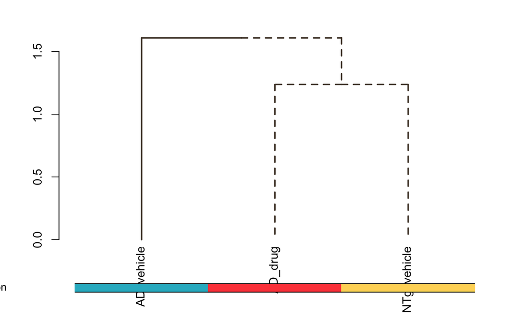

```r
drug_clust_boot_svd %>% pvrect(alpha=0.9, pv="au")
#dev.off()

## colours for dendrogram branches
clust_cols_ms1_svd <- c("#48392A", "#48392A")

ad_dend <- color_branches(as.dendrogram(drug_clust_svd), k = 2, col = clust_cols_ms1_svd) %>%
    set("branches_lwd", 2)

k_2 <- cutree(ad_dend, k = 2, order_clusters_as_data = FALSE)
ad_dend <- branches_attr_by_clusters(
  ad_dend,
  clusters = k_2,
  values = c(1,2),
  attr =  "lty"
)
## metadata for clustr heatmap
# red, blue, yellow
##"#FE4A49", "#2AB7CA", "#FED766"

cor_meta_svd <- data.frame(Sample = labels(ad_dend)) %>%
    mutate(#AD = case_when(str_detect(Sample, 'AD') ~ '#1446A0',
            #              str_detect(Sample, 'NTg') ~ '#DB3069'),
   # Drug = case_when(str_detect(Sample, '-D-') ~ '#F57251',
    #                      str_detect(Sample, '-V-') ~ '#3444DA'),
    #Time = case_when(str_detect(Sample, '-10') ~ '#131112',
    #                      str_detect(Sample, '-14') ~ '#F7F7FF'),
    Condition = case_when(str_detect(Sample, 'AD_drug') ~ '#FE4A49',
                          str_detect(Sample, 'AD_vehicle') ~ '#2AB7CA',
                          str_detect(Sample, 'NTg_vehicle') ~ '#FED766'))



k_2 <- cutree(ad_dend, k = 2, order_clusters_as_data = FALSE)
ad_dend <- ad_dend %>% set_labels(.,
                                  labels = c("AD_vehicle", "AD_drug", "NTg_vehicle"))
#ac_ibd_dend <- ac_ibd_dend %>% set_labels(., labels = c("CD", "UC (infl.)",
#                                                        "Control", "CD (infl.)", #"UC"))
#pdf(here::here("Dataset5-AD_mice", "CT10", "AD-mice-CT10-dend.pdf"))
ad_dend %>% plot()
colored_bars(colors = cor_meta_svd %>% dplyr::select(-Sample), dend = ad_dend, sort_by_labels_order = FALSE, y_shift=-.35)
```

```r
#dev.off()
```

### Clustering CT14

```r
kmedoid_labels_CT14 <- read.csv(here::here("Dataset5-AD_mice", "CT14", "k-med_labels.csv"), header=F) %>% as.vector()

#kmedoid_labels_CT14 <- read.csv(here::here("Dataset5-AD_mice", "CT14", "k-med_labels.csv"), header=F) %>% as.vector()



clusterinfoCT14 <- kmedoid_labels_CT14 %>% data.frame()
#clusterinfoCT14 <- kmedoid_labels_CT14 %>% data.frame()


max_clust_CT14 <- kmedoid_labels_CT14 %>% unique() %>% max()
print(paste("Number of clusters all data points:", max_clust+1))
```

```
[1] "Number of clusters all data points: 10"
```

```r
clusters <- list()
## creating a list that contains intensities of each peptide cluster
for (x in 0:max_clust){
    clustername <- paste("Cluster", x)
    y <- kmedoid_labels_CT14[which(kmedoid_labels_CT14$V1 == x),,drop=F] %>% rownames()
    intensities <- CT14[y %>% as.numeric(),] %>% as.data.frame()
    intensities <- intensities %>% mutate(feat_num = y)
    clusters[[clustername]] <- intensities
}

### eigenfactors
### Singular value decomposition for genome-wide expression data processing and modeling
###  https://doi.org/10.1073/pnas.97.18.10101
## https://www.biostars.org/p/299167/
## eigengenes <- svd(X)$v


svd_clusters <- lapply(clusters, function(x) svd(x %>% dplyr::select(-feat_num))$v)
# grabbing the first principal component
svd1_cluster <- lapply(svd_clusters,  "[", , 1)


clustereigenfactors_svd <- bind_cols(svd1_cluster) %>% data.frame()
```

```r
## make a factored dataframe of the compounds

datTraits <- data.frame(Condition =  as.factor(CT14_metadata$Condition))
rownames(datTraits) <- CT14_metadata$NewName
traits <- model.matrix(~ ., data=datTraits,
                       contrasts.arg = lapply(datTraits, contrasts, contrasts=FALSE))
traits <- traits[,-1] ##removing intercept
#moduleTraitCor_pca <- stats::cor(clustereigenfactors_pca, traits, method = "s")
moduleTraitCor_svd <- stats::cor(clustereigenfactors_svd, traits, method = "s")
#colnames(moduleTraitCor_pca) <- colnames(moduleTraitCor_pca) %>% substr(., 10, nchar(colnames(moduleTraitCor_pca)))
colnames(moduleTraitCor_svd) <- colnames(moduleTraitCor_svd) %>% substr(., 10, nchar(colnames(moduleTraitCor_svd)))
```

Now, let’s look at *SVD-derived* eigenfeatures (this is the more common way of calculating an eigenfeature).

```r
module_clust_svd <- hclust(as.dist(1-cor(t(moduleTraitCor_svd), method="pearson")), method="average")
drug_clust_svd <- hclust(as.dist(1-cor(moduleTraitCor_svd, method="pearson")), method="average")
drug_clust_boot_svd <- pvclust(moduleTraitCor_svd, method.hclust="average",
                           method.dist="correlation", nboot=1000,
                           iseed=2248)

quick_sil <- function(hclust_out, distance, max_k){
  silhouette_score <- function(i){
    k=cutree(hclust_out,i)
    ss <- silhouette(k, 1-cor(distance, method="pearson"))
    mean(ss[, 3])
    }
  clustnum <- 2:max_k
  avg_sil <- sapply(clustnum, silhouette_score)
  avg_sil <- data.frame(num = clustnum, sil_score = avg_sil)
  avg_sil <- rbind(c(1,0), avg_sil)
  return(avg_sil)
}
#
ms1_svd_sil <- quick_sil(hclust_out=drug_clust_svd, distance = 1-cor(moduleTraitCor_svd, method="pearson"), max_k = 2)
(ms1_sil <- ggplot(ms1_svd_sil, aes(x=num, y = sil_score)) +
  geom_point(size=4, colour="#F25C54", alpha=1) +
    geom_line(size=2, alpha=0.4) +
    geom_vline(xintercept=2, size = 2, linetype="dashed", color = "#38618C") +
    xlab("Number of clusters") +
    ylab("Average Silhouette Score") +
    scale_x_continuous(breaks = 1:30) +
    theme_classic(base_size=14) +
    ggtitle("AD-mice MS1-only clusters")
)

## Visualize the bootstrap clusters
clust_boot_svd <- as.dendrogram(drug_clust_boot_svd)
#pdf(here::here("figs", "ms1_bootstrap_dend.pdf"), width=9, height =4)
drug_clust_boot_svd %>% as.dendrogram() %>% plot(main = "MS1")
drug_clust_boot_svd %>% text
drug_clust_boot_svd %>% pvrect(alpha=0.9, pv="au")
#dev.off()

## colours for dendrogram branches
clust_cols_ms1_svd <- c("#48392A", "#48392A")

ad_dend <- color_branches(as.dendrogram(drug_clust_svd), k = 2, col = clust_cols_ms1_svd) %>%
    set("branches_lwd", 2)

k_2 <- cutree(ad_dend, k = 2, order_clusters_as_data = FALSE)
ad_dend <- branches_attr_by_clusters(
  ad_dend,
  clusters = k_2,
  values = c(1,2),
  attr =  "lty"
)
## metadata for clustr heatmap
# red, blue, yellow
##"#FE4A49", "#2AB7CA", "#FED766"

cor_meta_svd <- data.frame(Sample = labels(ad_dend)) %>%
    mutate(#AD = case_when(str_detect(Sample, 'AD') ~ '#1446A0',
            #              str_detect(Sample, 'NTg') ~ '#DB3069'),
   # Drug = case_when(str_detect(Sample, '-D-') ~ '#F57251',
    #                      str_detect(Sample, '-V-') ~ '#3444DA'),
    #Time = case_when(str_detect(Sample, '-10') ~ '#131112',
    #                      str_detect(Sample, '-14') ~ '#F7F7FF'),
    Condition = case_when(str_detect(Sample, 'AD_drug') ~ '#FE4A49',
                          str_detect(Sample, 'AD_vehicle') ~ '#2AB7CA',
                          str_detect(Sample, 'NTg_vehicle') ~ '#FED766'))



k_2 <- cutree(ad_dend, k = 2, order_clusters_as_data = FALSE)
ad_dend <- ad_dend %>% set_labels(.,
                                  labels = c("AD_vehicle", "AD_drug", "NTg_vehicle"))
#ac_ibd_dend <- ac_ibd_dend %>% set_labels(., labels = c("CD", "UC (infl.)",
#                                                        "Control", "CD (infl.)", #"UC"))
#pdf(here::here("Dataset5-AD_mice", "CT14", "AD-mice-CT14-dend.pdf"))
ad_dend %>% plot()
colored_bars(colors = cor_meta_svd %>% dplyr::select(-Sample), dend = ad_dend, sort_by_labels_order = FALSE, y_shift=-.35)
#dev.off()
```

[output not shown]